# chapter5

khorloo batpurev

2023-12-03

# Week 5 - Dimension reduction

### **Part 1 - Data manipulation**

I saved this file locally on my computer

```r
humandata<-read_csv("human_data_for_ex5.csv")
glimpse(humandata)
```

```
## Rows: 195
## Columns: 19
## $ hdi_rank          <dbl> 1, 2, 3, 4, 5, 6, 6, 8, 9, 9, 11, 12, 13, 14, 14, 16…
## $ Country           <chr> "Norway", "Australia", "Switzerland", "Denmark", "Ne…
## $ hdi               <dbl> 0.944, 0.935, 0.930, 0.923, 0.922, 0.916, 0.916, 0.9…
## $ life_exp          <dbl> 81.6, 82.4, 83.0, 80.2, 81.6, 80.9, 80.9, 79.1, 82.0…
## $ exp_edu           <dbl> 17.5, 20.2, 15.8, 18.7, 17.9, 16.5, 18.6, 16.5, 15.9…
## $ mean_edu          <dbl> 12.6, 13.0, 12.8, 12.7, 11.9, 13.1, 12.2, 12.9, 13.0…
## $ gni_per_cap       <dbl> 64992, 42261, 56431, 44025, 45435, 43919, 39568, 529…
## $ gni_diff_hdi      <dbl> 5, 17, 6, 11, 9, 11, 16, 3, 11, 23, -7, -2, -10, -1,…
## $ gii_rank          <dbl> 1, 2, 3, 4, 5, 6, 6, 8, 9, 9, 11, 12, 13, 14, 14, 16…
## $ gii               <dbl> 0.067, 0.110, 0.028, 0.048, 0.062, 0.041, 0.113, 0.2…
## $ mat_mort          <dbl> 4, 6, 6, 5, 6, 7, 9, 28, 11, 8, 6, NA, NA, 4, 8, 4, …
## $ ad_birth          <dbl> 7.8, 12.1, 1.9, 5.1, 6.2, 3.8, 8.2, 31.0, 14.5, 25.3…
## $ perc_parl         <dbl> 39.6, 30.5, 28.5, 38.0, 36.9, 36.9, 19.9, 19.4, 28.2…
## $ fem_sec           <dbl> 97.4, 94.3, 95.0, 95.5, 87.7, 96.3, 80.5, 95.1, 100.…
## $ male_sec          <dbl> 96.7, 94.6, 96.6, 96.6, 90.5, 97.0, 78.6, 94.8, 100.…
## $ fem_part          <dbl> 61.2, 58.8, 61.8, 58.7, 58.5, 53.6, 53.1, 56.3, 61.6…
## $ male_part         <dbl> 68.7, 71.8, 74.9, 66.4, 70.6, 66.4, 68.1, 68.9, 71.0…
## $ prop_secondary_ed <dbl> 1.0072389, 0.9968288, 0.9834369, 0.9886128, 0.969060…
## $ prop_labour       <dbl> 0.8908297, 0.8189415, 0.8251001, 0.8840361, 0.828611…
```

This is a global dataset including main economic and socio-demographic variables that is aimed at measuring gender inequality in the work force. There are 195 countries (rows in the dataset) and 19 columns. The below header shows the details of the columns in the dataset.

- *hdi_rank = HDI Rank*
- *hdi = Human Development Index (HDI)*
- *life_exp=Life Expectancy at Birth*
- *exp_edu=Expected Years of Education*
- *mean_edu=Mean Years of Education*
- *gni_per_cap=Gross National Income (GNI) per Capita*
- *gni_diff_hdi=GNI per Capita Rank Minus HDI Rank*
- *gii_rank=GII Rank*
- *gii=Gender Inequality Index (GII)*
- *mat_mort=Maternal Mortality Ratio*
- *ad_birth=Adolescent Birth Rate*
- *perc_parl=Percent Representation in Parliament*
- *fem_sec=Population with Secondary Education (Female)*
- *male_sec=Population with Secondary Education (Male)*
- *fem_part=Labour Force Participation Rate (Female)*
- *male_part=Labour Force Participation Rate (Male)*

```r
#Removing columns that aren't necessary
complete_fem<- dplyr::select(humandata, c( "Country", "fem_sec", "fem_part", "exp_edu", "life_exp", "gni_per_cap", "mat_mort", "ad_birth", "perc_parl"))

#Checking if there is NAs in the rows
complete.cases(complete_fem)
```

```
##   [1]  TRUE  TRUE  TRUE  TRUE  TRUE  TRUE  TRUE  TRUE  TRUE  TRUE  TRUE FALSE
##  [13] FALSE  TRUE  TRUE  TRUE  TRUE  TRUE  TRUE  TRUE  TRUE  TRUE  TRUE  TRUE
##  [25]  TRUE  TRUE  TRUE  TRUE  TRUE  TRUE FALSE  TRUE  TRUE FALSE  TRUE  TRUE
##  [37]  TRUE  TRUE  TRUE  TRUE  TRUE  TRUE  TRUE  TRUE  TRUE  TRUE  TRUE  TRUE
##  [49]  TRUE  TRUE  TRUE  TRUE  TRUE  TRUE  TRUE  TRUE  TRUE FALSE  TRUE FALSE
##  [61]  TRUE  TRUE  TRUE FALSE  TRUE  TRUE  TRUE  TRUE  TRUE  TRUE  TRUE  TRUE
##  [73]  TRUE  TRUE  TRUE  TRUE FALSE  TRUE FALSE  TRUE  TRUE  TRUE  TRUE  TRUE
##  [85]  TRUE  TRUE  TRUE  TRUE FALSE  TRUE  TRUE  TRUE  TRUE FALSE  TRUE  TRUE
##  [97]  TRUE FALSE  TRUE  TRUE  TRUE  TRUE  TRUE  TRUE  TRUE  TRUE  TRUE  TRUE
## [109] FALSE  TRUE  TRUE  TRUE FALSE FALSE  TRUE  TRUE  TRUE  TRUE  TRUE  TRUE
## [121]  TRUE FALSE FALSE  TRUE  TRUE  TRUE  TRUE  TRUE  TRUE  TRUE  TRUE  TRUE
## [133] FALSE  TRUE FALSE  TRUE FALSE FALSE  TRUE  TRUE FALSE  TRUE  TRUE FALSE
## [145]  TRUE  TRUE  TRUE  TRUE FALSE  TRUE  TRUE FALSE  TRUE FALSE  TRUE  TRUE
## [157] FALSE  TRUE FALSE  TRUE  TRUE  TRUE  TRUE  TRUE  TRUE  TRUE  TRUE FALSE
## [169] FALSE  TRUE  TRUE  TRUE  TRUE  TRUE  TRUE  TRUE  TRUE FALSE  TRUE  TRUE
## [181]  TRUE FALSE  TRUE  TRUE  TRUE FALSE  TRUE  TRUE  TRUE  TRUE  TRUE  TRUE
## [193]  TRUE  TRUE  TRUE
```

```r
#Removing rows that have at least one NA
complete_fem<-complete_fem[complete.cases(complete_fem),]

#Only keeping countries of the world (removing averaged regions)
#The last 7 rows are all related to regions so we remove them by identifying the rows counting from the bottom up.
last <- nrow(complete_fem) - 7
complete_fem<-complete_fem[1:last, ]
glimpse(complete_fem)
```

```
## Rows: 155
## Columns: 9
## $ Country     <chr> "Norway", "Australia", "Switzerland", "Denmark", "Netherla…
## $ fem_sec     <dbl> 97.4, 94.3, 95.0, 95.5, 87.7, 96.3, 80.5, 95.1, 100.0, 95.…
## $ fem_part    <dbl> 61.2, 58.8, 61.8, 58.7, 58.5, 53.6, 53.1, 56.3, 61.6, 62.0…
## $ exp_edu     <dbl> 17.5, 20.2, 15.8, 18.7, 17.9, 16.5, 18.6, 16.5, 15.9, 19.2…
## $ life_exp    <dbl> 81.6, 82.4, 83.0, 80.2, 81.6, 80.9, 80.9, 79.1, 82.0, 81.8…
## $ gni_per_cap <dbl> 64992, 42261, 56431, 44025, 45435, 43919, 39568, 52947, 42…
## $ mat_mort    <dbl> 4, 6, 6, 5, 6, 7, 9, 28, 11, 8, 6, 4, 8, 4, 27, 2, 11, 6, …
## $ ad_birth    <dbl> 7.8, 12.1, 1.9, 5.1, 6.2, 3.8, 8.2, 31.0, 14.5, 25.3, 6.0,…
## $ perc_parl   <dbl> 39.6, 30.5, 28.5, 38.0, 36.9, 36.9, 19.9, 19.4, 28.2, 31.4…
```

### **Part 2 - Analysis - dimension reduction**

#### **Task 1**

```r
library(tibble)
complete_fem1<-column_to_rownames(complete_fem,"Country")
str(complete_fem1)
```

```
## 'data.frame':    155 obs. of  8 variables:
##  $ fem_sec    : num  97.4 94.3 95 95.5 87.7 96.3 80.5 95.1 100 95 ...
##  $ fem_part   : num  61.2 58.8 61.8 58.7 58.5 53.6 53.1 56.3 61.6 62 ...
##  $ exp_edu    : num  17.5 20.2 15.8 18.7 17.9 16.5 18.6 16.5 15.9 19.2 ...
##  $ life_exp   : num  81.6 82.4 83 80.2 81.6 80.9 80.9 79.1 82 81.8 ...
##  $ gni_per_cap: num  64992 42261 56431 44025 45435 ...
##  $ mat_mort   : num  4 6 6 5 6 7 9 28 11 8 ...
##  $ ad_birth   : num  7.8 12.1 1.9 5.1 6.2 3.8 8.2 31 14.5 25.3 ...
##  $ perc_parl  : num  39.6 30.5 28.5 38 36.9 36.9 19.9 19.4 28.2 31.4 ...
```

```r
#Data visualisation
library(psych)
```

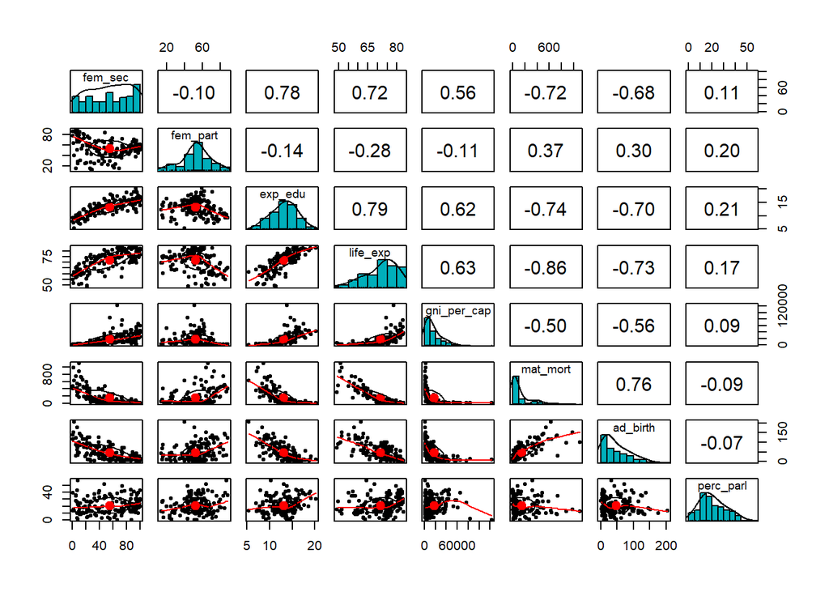

```r
pairs.panels(complete_fem1,
             method = "pearson", # correlation method
             hist.col = "#00AFBB",
             density = TRUE,  # show density plots
             )
```

Diagonal rows in blue histogram shows the distribution of the variables and the bottow left panels show the paired relationship between the variables (down and across). The top right panels show the Pearson correlation coefficients.

##### **Distributions of variables**

*Normally distributed* - Labour participiation of females (fem_part) and expected years of education (exp_edu)

##### **Relationship between variables**

*Positively correlated variables > Pearson correlation coefficient of 0.72*

Life expectancy and expected years of education have positive linear relationship with Pearson correlation coefficient of 0.79. This suggests that these demographic variables are highly correlated, generally speaking more education and better health go hand in hand (though not necessarily causal).

Expected years of education and proportion of females with secondary education have positive correlation (it may not be strictly linear). This is expected, more secondary educated women will raise the number of years education is continued for the population,

Maternal mortality and adolescent birth rate are also positively correlated, suggesting that mothers’ life are at risk when adolescent birth rate is high.

*Negatively correlated variables < -0.72*

Life expectancy and maternal mortality have strong negative correlation, which suggests that when maternal mortality rate increases, life expectancy levels decrease. The Pearson correlation coefficient for this two variables is -0.86. The relationship doesn’t look linear, it is more like a decay shape (at life expectancy rate goes higher, the maternal mortality rate continually drops).

Life expectancy is also negatively correlated with adolescent birth. Similarly as above, as life expectancy increases, adolescent birth rate decreases. The interpretation should be carefully thought through here, i think there is a danger of interpreting this as a sign to say as people get older it is less likely to give birth (adolescent), which certainly makes sense on face value. Hwoever, what i think this is suggesting is that generally speaking, at population level when life expectancy increases (healthier, more educated society), then adolescent birth rates drop due to better social and health care.

Expected education years and maternal mortality rate are also negatively correlated, suggesting that as the number of years people spend being educated increases, material mortality rate drops (Pearson’s correlation coefficient -0.74).

#### **Task 2**

```r
library(factoextra)
```

```r
#I prefer factoextra for pca visualisation as it links to ggplot

complete_fem$Country<-as.factor(complete_fem$Country)
pca<-prcomp(complete_fem[,c(2:9)], scale=FALSE,center = FALSE) #we don't include country here because it is not numeric.
summary(pca)
```

```
## Importance of components:
##                              PC1       PC2      PC3   PC4   PC5   PC6   PC7
## Standard deviation     2.563e+04 267.23909 60.25614 25.92 14.96 12.31 10.43
## Proportion of Variance 9.999e-01   0.00011  0.00001  0.00  0.00  0.00  0.00
## Cumulative Proportion  9.999e-01   0.99999  1.00000  1.00  1.00  1.00  1.00
##                          PC8
## Standard deviation     1.433
## Proportion of Variance 0.000
## Cumulative Proportion  1.000
```

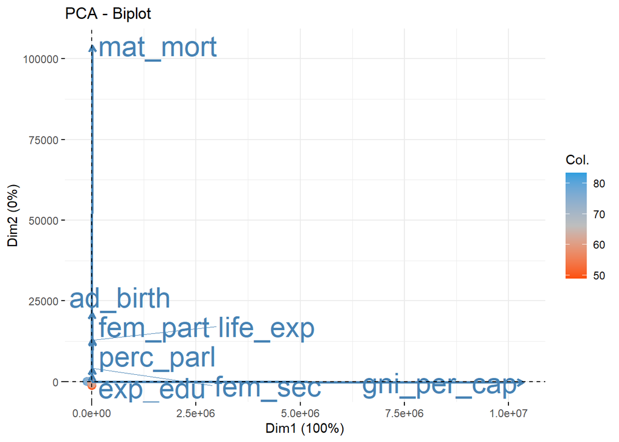

```r
cluster_score<-fviz_pca_biplot(pca,geom="point",label = "var",axes=c(1,2),col.ind = complete_fem$life_exp, pointsize = 3,gradient.cols = c("#FC4E07","grey","#2E9FDF"),addEllipses=FALSE, ggtheme = theme_minimal(),repel = TRUE,labelsize=8,arrowsize=1)
cluster_score
```

This doesn’t look right. Basically what its doing is that its drawing the covariance matrix of the raw dataset. The matrix hasn’t been “decomposed”, or lower dimensions aren’t being extracted when data isn’t standardised.

#### **Task 3**

```r
#Note what i changed scale=TRUE and center=TRUE
library(factoextra)
#I prefer factoextra for pca visualisation as it links to ggplot

complete_fem$Country<-as.factor(complete_fem$Country)
pca<-prcomp(complete_fem[,c(2:9)], scale=TRUE,center = TRUE) #we don't include country here because it is not numeric.
summary(pca)
```

```
## Importance of components:
##                           PC1    PC2     PC3     PC4     PC5    PC6     PC7
## Standard deviation     2.1360 1.1171 0.87671 0.72027 0.55309 0.5299 0.44935
## Proportion of Variance 0.5703 0.1560 0.09608 0.06485 0.03824 0.0351 0.02524
## Cumulative Proportion  0.5703 0.7263 0.82235 0.88720 0.92544 0.9605 0.98578
##                            PC8
## Standard deviation     0.33728
## Proportion of Variance 0.01422
## Cumulative Proportion  1.00000
```

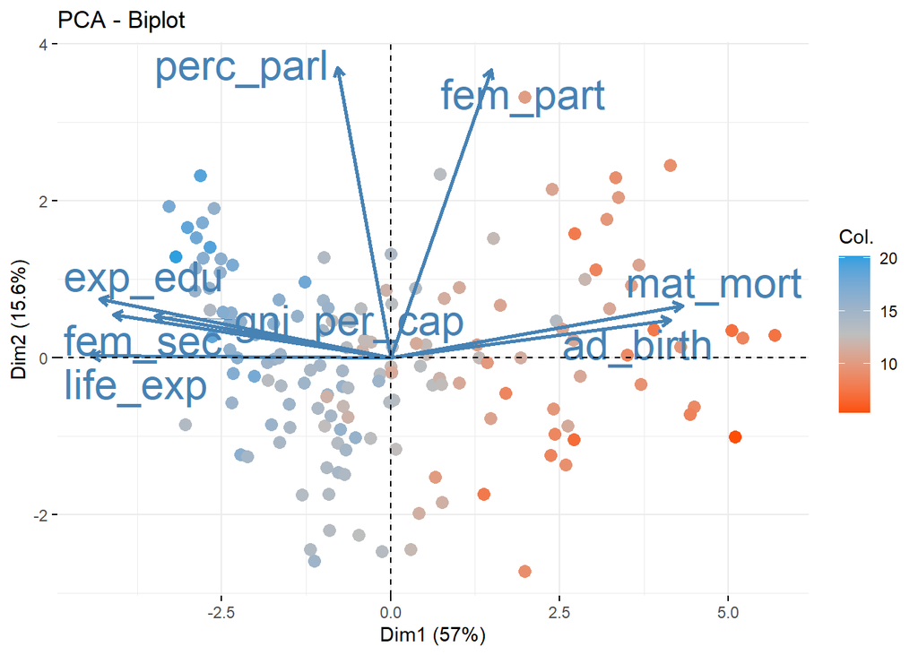

```r
cluster_score<-fviz_pca_biplot(pca,geom="point",label = "var",axes=c(1,2),col.ind = complete_fem$exp_edu, pointsize = 3,gradient.cols = c("#FC4E07","grey","#2E9FDF"),addEllipses=FALSE, ggtheme = theme_minimal(),repel = TRUE,labelsize=8,arrowsize=1)
cluster_score
```

Lets see what the other dimensions look like.

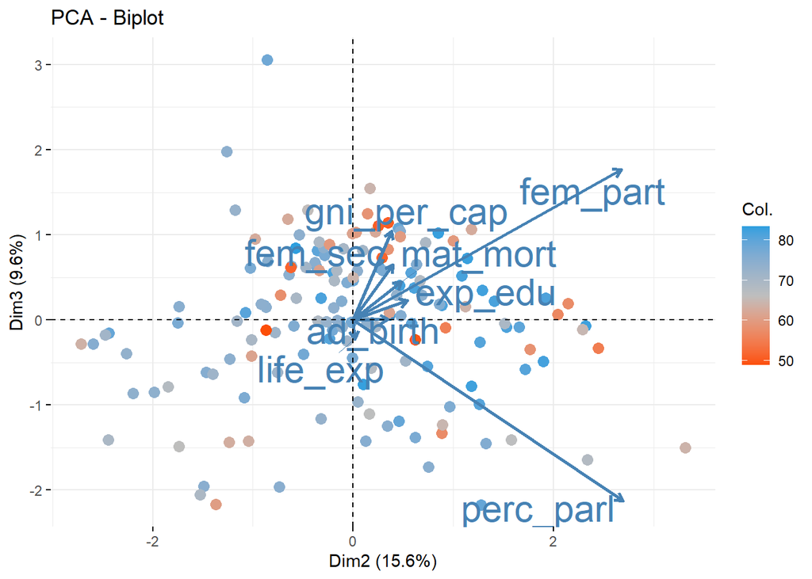

```r
#Note i changed axes = c(2,3)
cluster_score<-fviz_pca_biplot(pca,geom="point",label = "var",axes=c(2,3),col.ind = complete_fem$life_exp, pointsize = 3,gradient.cols = c("#FC4E07","grey","#2E9FDF"),addEllipses=FALSE, ggtheme = theme_minimal(),repel = TRUE,labelsize=8,arrowsize=1)
cluster_score
```

#### **Task 4**

As i have included fair bit of interpretation above, I am now going to try and visualise the data by GNI to see what it has on the rest of the social variables.

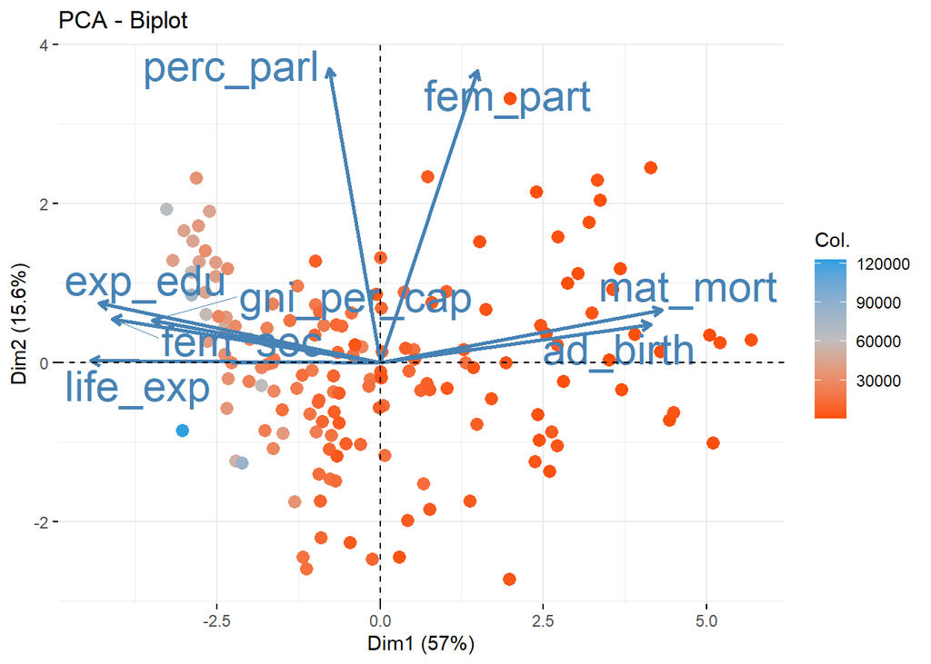

```r
cluster_score<-fviz_pca_biplot(pca,geom="point",label = "var",axes=c(1,2),col.ind = complete_fem$gni_per_cap, pointsize = 3,gradient.cols = c("#FC4E07","grey","#2E9FDF"),addEllipses=FALSE, ggtheme = theme_minimal(),repel = TRUE,labelsize=8,arrowsize=1)
cluster_score
```

This shows that the majority of 155 countries in the dataset have GNI of around 30000 or less USD per annum. In low income countries maternal moralities, adolescent birth rates are high and so is female participation in the labour force. The positioning of the arrows (red colour on the opposite direction to life expectancy and expected education years) mean that in lower income countries, life expectancy and proportion of females with secondary education are low. The higher income countries (blue and grey dots) are very few and they are associated with high life expectancy, proportion of females with secondary education. This PCA result summarises the social and gender inequity across the world.

#### **Task 5**

```r
tea <- read.csv("https://raw.githubusercontent.com/KimmoVehkalahti/Helsinki-Open-Data-Science/master/datasets/tea.csv", stringsAsFactors = TRUE)
View(tea)
str(tea) #Only 1 numeric value (age) and the rest are factors!
```

```
## 'data.frame':    300 obs. of  36 variables:
##  $ breakfast       : Factor w/ 2 levels "breakfast","Not.breakfast": 1 1 2 2 1 2 1 2 1 1 ...
##  $ tea.time        : Factor w/ 2 levels "Not.tea time",..: 1 1 2 1 1 1 2 2 2 1 ...
##  $ evening         : Factor w/ 2 levels "evening","Not.evening": 2 2 1 2 1 2 2 1 2 1 ...
##  $ lunch           : Factor w/ 2 levels "lunch","Not.lunch": 2 2 2 2 2 2 2 2 2 2 ...
##  $ dinner          : Factor w/ 2 levels "dinner","Not.dinner": 2 2 1 1 2 1 2 2 2 2 ...
##  $ always          : Factor w/ 2 levels "always","Not.always": 2 2 2 2 1 2 2 2 2 2 ...
##  $ home            : Factor w/ 2 levels "home","Not.home": 1 1 1 1 1 1 1 1 1 1 ...
##  $ work            : Factor w/ 2 levels "Not.work","work": 1 1 2 1 1 1 1 1 1 1 ...
##  $ tearoom         : Factor w/ 2 levels "Not.tearoom",..: 1 1 1 1 1 1 1 1 1 2 ...
##  $ friends         : Factor w/ 2 levels "friends","Not.friends": 2 2 1 2 2 2 1 2 2 2 ...
##  $ resto           : Factor w/ 2 levels "Not.resto","resto": 1 1 2 1 1 1 1 1 1 1 ...
##  $ pub             : Factor w/ 2 levels "Not.pub","pub": 1 1 1 1 1 1 1 1 1 1 ...
##  $ Tea             : Factor w/ 3 levels "black","Earl Grey",..: 1 1 2 2 2 2 2 1 2 1 ...
##  $ How             : Factor w/ 4 levels "alone","lemon",..: 1 3 1 1 1 1 1 3 3 1 ...
```

[output cut: 22 more lines]

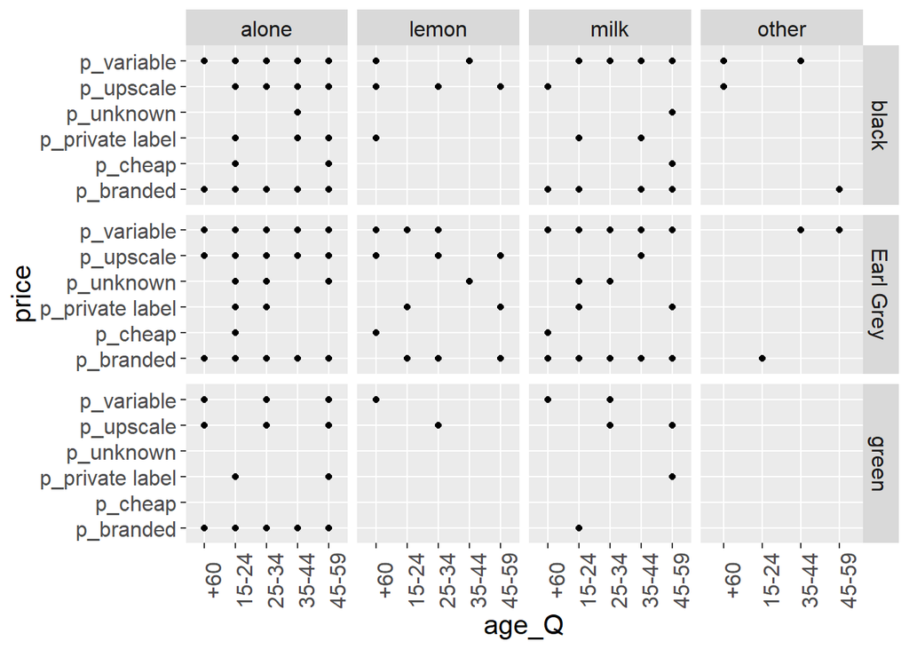

```r
library(ggplot2)
interest_plot<-ggplot(data = tea, aes(y=price,x=age_Q)) +
      geom_point()+
      theme(text = element_text(size=15))+facet_grid(Tea~How,scales="free_x")+
      theme(axis.text.x = element_text(angle=90))
interest_plot
```

This is just a basic question about how different age group people take their tea (what type as well as how) and what price they are willing to pay for it. It makes sense.

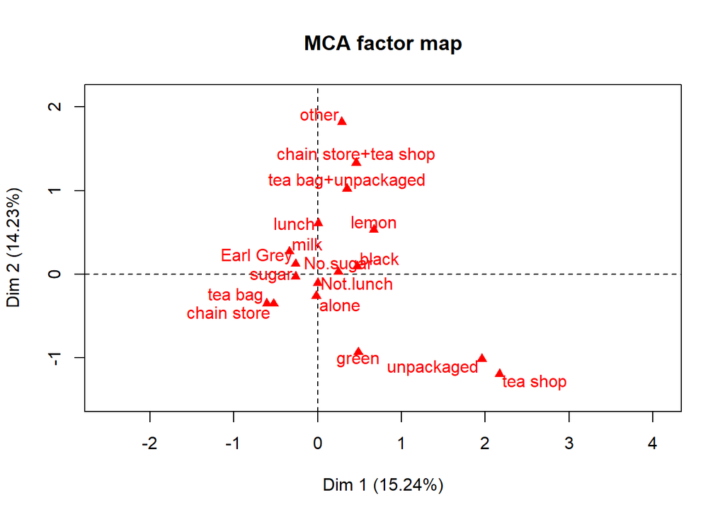

```r
# select variables of interest to create a new dataset
tea_time <- dplyr::select(tea, c("Tea", "How", "how", "sugar", "where", "lunch"))
library(FactoMineR)
mca <- MCA(tea_time, graph = FALSE)
plot(mca, invisible=c("ind"), graph.type = "classic")
```

Total variance explained in dimension 1 and 2 is around 30%. Unpackaged tea tend to be sold in tea shop whilst tea bags are more associated with chain stores. Earl greys are generally not for lunch, milk is generally taken with sugar rather than lemon. This all makes sense.

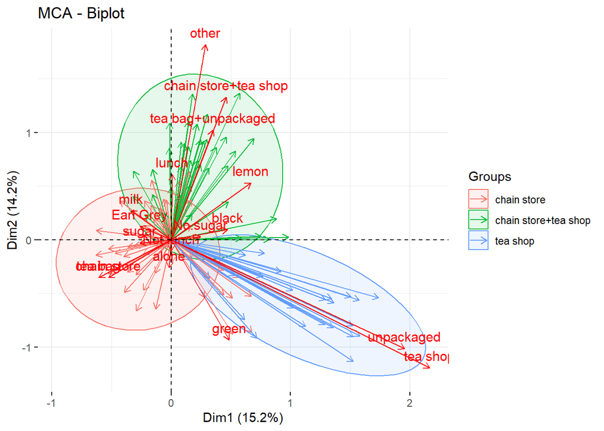

```r
library(factoextra)
fviz_mca_biplot(mca, axes = c(1, 2), geom = "text",
  geom.ind = "var", repel = FALSE, label = "all",
  invisible = "none", habillage = tea_time$where, addEllipses = TRUE,
  palette = NULL, arrows = c(TRUE,TRUE), map = "symmetric")
```

This is visualised by where tea is sold and clumped accordingly. As mentioned earlier, loose leaf and green tea are generally associated with tea merchants in specialised tea shops. Black tea taken with lunch can be either sold in chain stores or in tea shops. Whilst Early Grey and tea bags are almost exclusively associated with chain stores.